# 04_cake_frosting

## 04_cake_frosting

#### Question

1. A three-tiered cake is constructed with three cylinders. Each cylinder has a height of 16 centimeters. The radii are 9 centimeters, 19 centimeters, and 29 centimeters.

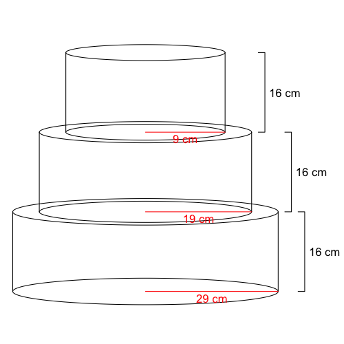

   We wish to calculate the area covered by frosting.

   Each cylinder’s sides are covered. The area of a cylinder’s sides can be found using the following formula where $r$ is the radius and $h$ is the height.

   $$A_{\mathrm{side}} ~=~ 2\pi r h$$

   The tops are also frosted. You might think you would need to find the areas of all three, but actually, you can just find the area of the top of the largest cylinder. The top of the cylinder is a circle.

   $$A_{\mathrm{top}}~=~ \pi r^2$$

   How much area (in square centimeters) is frosted?

#### Question

2. A three-tiered cake is constructed with three cylinders. Each cylinder has a height of 9 centimeters. The radii are 12 centimeters, 18 centimeters, and 24 centimeters.

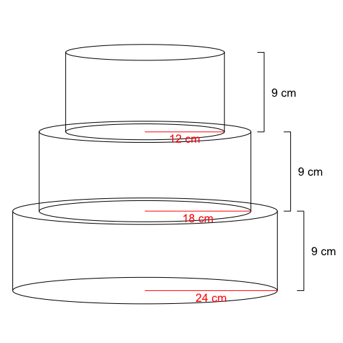

   We wish to calculate the area covered by frosting.

   Each cylinder’s sides are covered. The area of a cylinder’s sides can be found using the following formula where $r$ is the radius and $h$ is the height.

   $$A_{\mathrm{side}} ~=~ 2\pi r h$$

   The tops are also frosted. You might think you would need to find the areas of all three, but actually, you can just find the area of the top of the largest cylinder. The top of the cylinder is a circle.

   $$A_{\mathrm{top}}~=~ \pi r^2$$

   How much area (in square centimeters) is frosted?

#### Question

3. A three-tiered cake is constructed with three cylinders. Each cylinder has a height of 9 centimeters. The radii are 8 centimeters, 12 centimeters, and 16 centimeters.

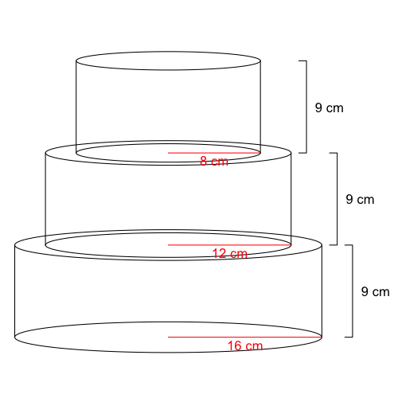

   We wish to calculate the area covered by frosting.

   Each cylinder’s sides are covered. The area of a cylinder’s sides can be found using the following formula where $r$ is the radius and $h$ is the height.

   $$A_{\mathrm{side}} ~=~ 2\pi r h$$

   The tops are also frosted. You might think you would need to find the areas of all three, but actually, you can just find the area of the top of the largest cylinder. The top of the cylinder is a circle.

   $$A_{\mathrm{top}}~=~ \pi r^2$$

   How much area (in square centimeters) is frosted?

#### Question

4. A three-tiered cake is constructed with three cylinders. Each cylinder has a height of 12 centimeters. The radii are 15 centimeters, 24 centimeters, and 33 centimeters.

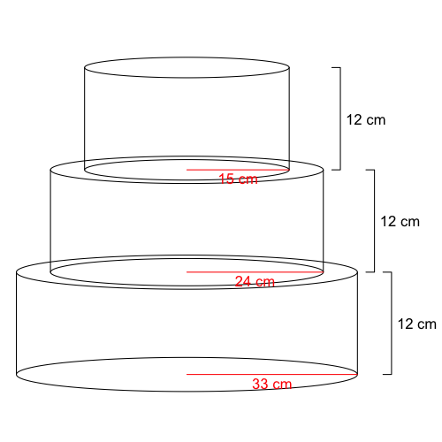

   We wish to calculate the area covered by frosting.

   Each cylinder’s sides are covered. The area of a cylinder’s sides can be found using the following formula where $r$ is the radius and $h$ is the height.

   $$A_{\mathrm{side}} ~=~ 2\pi r h$$

   The tops are also frosted. You might think you would need to find the areas of all three, but actually, you can just find the area of the top of the largest cylinder. The top of the cylinder is a circle.

   $$A_{\mathrm{top}}~=~ \pi r^2$$

   How much area (in square centimeters) is frosted?

#### Question

5. A three-tiered cake is constructed with three cylinders. Each cylinder has a height of 17 centimeters. The radii are 12 centimeters, 16 centimeters, and 20 centimeters.

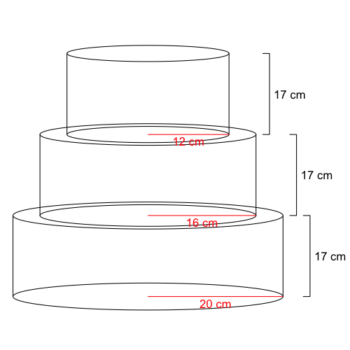

   We wish to calculate the area covered by frosting.

   Each cylinder’s sides are covered. The area of a cylinder’s sides can be found using the following formula where $r$ is the radius and $h$ is the height.

   $$A_{\mathrm{side}} ~=~ 2\pi r h$$

   The tops are also frosted. You might think you would need to find the areas of all three, but actually, you can just find the area of the top of the largest cylinder. The top of the cylinder is a circle.

   $$A_{\mathrm{top}}~=~ \pi r^2$$

   How much area (in square centimeters) is frosted?

#### Question

6. A three-tiered cake is constructed with three cylinders. Each cylinder has a height of 12 centimeters. The radii are 10 centimeters, 14 centimeters, and 18 centimeters.

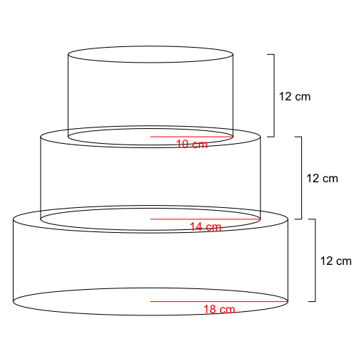

   We wish to calculate the area covered by frosting.

   Each cylinder’s sides are covered. The area of a cylinder’s sides can be found using the following formula where $r$ is the radius and $h$ is the height.

   $$A_{\mathrm{side}} ~=~ 2\pi r h$$

   The tops are also frosted. You might think you would need to find the areas of all three, but actually, you can just find the area of the top of the largest cylinder. The top of the cylinder is a circle.

   $$A_{\mathrm{top}}~=~ \pi r^2$$

   How much area (in square centimeters) is frosted?

#### Question

7. A three-tiered cake is constructed with three cylinders. Each cylinder has a height of 12 centimeters. The radii are 10 centimeters, 15 centimeters, and 20 centimeters.

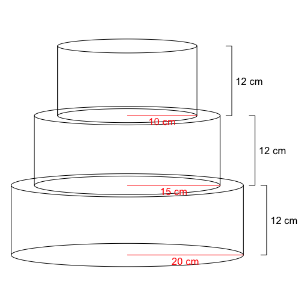

   We wish to calculate the area covered by frosting.

   Each cylinder’s sides are covered. The area of a cylinder’s sides can be found using the following formula where $r$ is the radius and $h$ is the height.

   $$A_{\mathrm{side}} ~=~ 2\pi r h$$

   The tops are also frosted. You might think you would need to find the areas of all three, but actually, you can just find the area of the top of the largest cylinder. The top of the cylinder is a circle.

   $$A_{\mathrm{top}}~=~ \pi r^2$$

   How much area (in square centimeters) is frosted?

#### Question

8. A three-tiered cake is constructed with three cylinders. Each cylinder has a height of 16 centimeters. The radii are 6 centimeters, 13 centimeters, and 20 centimeters.

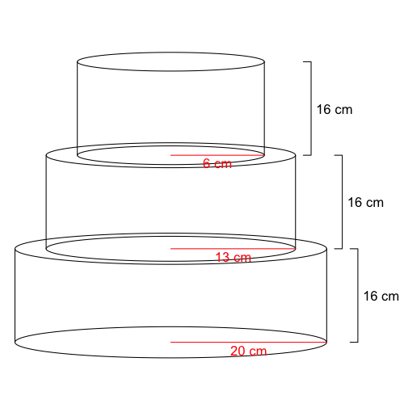

   We wish to calculate the area covered by frosting.

   Each cylinder’s sides are covered. The area of a cylinder’s sides can be found using the following formula where $r$ is the radius and $h$ is the height.

   $$A_{\mathrm{side}} ~=~ 2\pi r h$$

   The tops are also frosted. You might think you would need to find the areas of all three, but actually, you can just find the area of the top of the largest cylinder. The top of the cylinder is a circle.

   $$A_{\mathrm{top}}~=~ \pi r^2$$

   How much area (in square centimeters) is frosted?